# Highschool and Beyond Survey Analysis

Joshua Xavier

2026-09-14

# 1 Data set and Practical Questions

In this section we will go over the data set, practical questions asked about the data, and preform exploratory data analysis to create the best model of the data.

## 1.1 Data Description

The data set used in this project is the “hsb2” data set, an acronym for “high school and beyond”. The data set contains 200 randomly selected observations from the “High School and Beyond” survey, which was conducted by the National Center for Education Statistics and polled seniors in high school. The dataset uses 11 total variables, 1 identifying variable (id), 5 numerical variables, including the response variable write, and 5 categorical variables.

The dataset contains enough information to investigate these questions because it includes socioeconomic status, academic program, demographic characteristics, and multiple standardized test scores for 200 students, with 11 variables. This allows us to compare academic preformance across different groups and use statistical methods to determine whether a meaningful relationships exist.

- id: student id number
- write (Y): writing test score
- read (X1): reading test score
- math (X2): math test score
- science (X3): science test score
- socst (X4): social studies test score
- gender: student gender (2 levels)
- race: student race/ethnicity (4 levels)
- ses: socioeconomic status - low/middle/high (3 levels)
- schtyp: school type - public/private (2 levels)
- prog: program type - general/academic/vocational (3 levels)

```r
hsb2 <- read.csv("https://raw.githubusercontent.com/Joshuaxav/STA321F26/main/hsb2.csv")
hsb2$gender <- factor(hsb2$gender)
hsb2$race   <- factor(hsb2$race)
hsb2$ses    <- factor(hsb2$ses, levels = c("low", "middle", "high"))
hsb2$schtyp <- factor(hsb2$schtyp)
hsb2$prog   <- factor(hsb2$prog)
```

## 1.3 Exploratory Data Analysis

We first explore the pairwise association between the numerical variables in the data set.

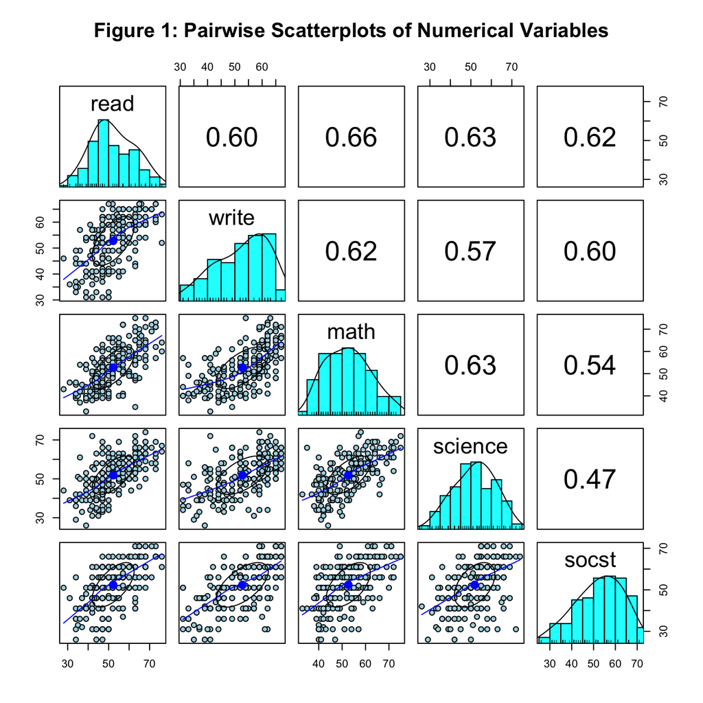

Figure 1: Pairwise scatter plot of numerical variables.

```r
pairs.panels(hsb2[, c("read", "write", "math", "science", "socst")],
             main = "Figure 1: Pairwise Scatterplots of Numerical Variables",
             pch = 21,
             bg = "lightblue")
```

The five variables all show a positive relationship with each other. In general, students who scored higher in one subject also scored higher in the others. Reading and math had the strongest relationship at 0.66, while science and social studies had the weakest at 0.47. It is also worth mentioning reading had a particularly strong relationship with the other subjects.

The points follow a fairly straight upward pattern, so a linear model appears to be appropriate for predicting writing scores from reading scores.

Because `read`, `math`, `science`, and `socst` are all correlated with one another (0.47–0.66), we will need to check for multicollinearity once they’re all in the same model together.

If a transformation is needed, we would transform the response variable. This is because the Box Cox transformation helps fix stabilize variance, normalize residuals, and improves linearity, which are tied to the response variable in a linear regression model.

# 2 Fitting MLR to Data

We use parametric and bootstrap regression models to assess the association between writing score and reading score

## 2.1 Raw Model and Diagnostics

We start with a model that includes every available predictor.

```r
full.model <- lm(write ~ read + math + science + socst +
                    gender + race + ses + schtyp + prog, data = hsb2)
kable(summary(full.model)$coef, digits = 4,
      caption = "Statistics of Regression Coefficients - Full Model")
```

Statistics of Regression Coefficients - Full Model

|  | Estimate | Std. Error | t value | Pr(>\|t\|) |
| --- | --- | --- | --- | --- |
| (Intercept) | 16.5335 | 3.6675 | 4.5082 | 0.0000 |
| read | 0.1162 | 0.0654 | 1.7775 | 0.0771 |
| math | 0.1745 | 0.0713 | 2.4471 | 0.0153 |
| science | 0.2556 | 0.0648 | 3.9433 | 0.0001 |
| socst | 0.2292 | 0.0556 | 4.1250 | 0.0001 |
| gendermale | -5.0987 | 0.8904 | -5.7260 | 0.0000 |
| raceasian | 4.5608 | 2.3750 | 1.9203 | 0.0563 |
| racehispanic | -0.8982 | 1.8512 | -0.4852 | 0.6281 |
| racewhite | 0.6980 | 1.5822 | 0.4412 | 0.6596 |
| sesmiddle | -1.2532 | 1.1756 | -1.0660 | 0.2878 |
| seshigh | -1.1124 | 1.3304 | -0.8361 | 0.4042 |
| schtyppublic | -1.1518 | 1.2164 | -0.9469 | 0.3449 |
| proggeneral | -1.3787 | 1.1928 | -1.1559 | 0.2492 |
| progvocational | -1.6514 | 1.2654 | -1.3050 | 0.1935 |

## 2.2 Multicollinearity Check (VIF)

Since the four numerical predictors are correlated with each other, we check the variance inflation factor before trusting any individual coefficient’s p-value.

```r
vif(full.model)
```

```
            GVIF Df GVIF^(1/(2*Df))
read    2.459203  1        1.568185
math    2.444804  1        1.563587
science 2.255715  1        1.501904
socst   1.949537  1        1.396258
gender  1.082281  1        1.040327
race    1.411828  3        1.059165
ses     1.364807  2        1.080856
schtyp  1.094740  1        1.046298
prog    1.659567  2        1.135007
```

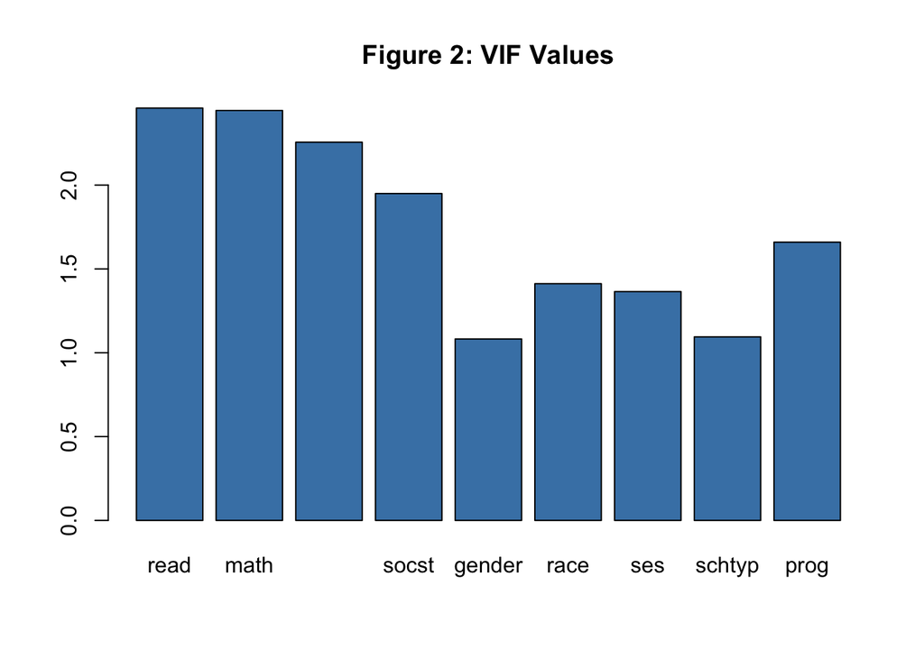

```r
barplot(vif(full.model)[, 1], main = "Figure 2: VIF Values", horiz = FALSE, col = "steelblue")
```

All VIFs are below 2.5, well under the threshold of 4-10, so multicollinearity is not a concern here despite the correlation seen in the pairwise plot.

Next, we conduct residual diagnostic analysis to check the validity of the model before making an inference about the model.

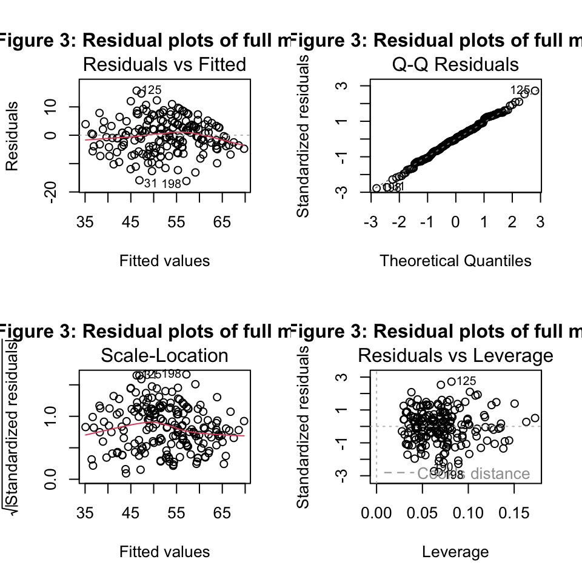

```r
par(mfrow = c(2, 2))
plot(full.model, main = "Figure 3: Residual plots of full model")
```

```r
tidy_model <- tidy(full.model)
kable(tidy_model, digits = 4,
      caption = paste0("Coefficient estimates (R² = ",
                        round(summary(full.model)$r.squared, 3), ")"))
```

Coefficient estimates (R² = 0.622)

| term | estimate | std.error | statistic | p.value |
| --- | --- | --- | --- | --- |
| (Intercept) | 16.5335 | 3.6675 | 4.5082 | 0.0000 |
| read | 0.1162 | 0.0654 | 1.7775 | 0.0771 |
| math | 0.1745 | 0.0713 | 2.4471 | 0.0153 |
| science | 0.2556 | 0.0648 | 3.9433 | 0.0001 |
| socst | 0.2292 | 0.0556 | 4.1250 | 0.0001 |
| gendermale | -5.0987 | 0.8904 | -5.7260 | 0.0000 |
| raceasian | 4.5608 | 2.3750 | 1.9203 | 0.0563 |
| racehispanic | -0.8982 | 1.8512 | -0.4852 | 0.6281 |
| racewhite | 0.6980 | 1.5822 | 0.4412 | 0.6596 |
| sesmiddle | -1.2532 | 1.1756 | -1.0660 | 0.2878 |
| seshigh | -1.1124 | 1.3304 | -0.8361 | 0.4042 |
| schtyppublic | -1.1518 | 1.2164 | -0.9469 | 0.3449 |
| proggeneral | -1.3787 | 1.1928 | -1.1559 | 0.2492 |
| progvocational | -1.6514 | 1.2654 | -1.3050 | 0.1935 |

The residual plots for the full model look reasonably good already, with no strong curve pattern and no obvious funnel shape. We revisit these diagnostics more formally after variable selection, since removing predictors can change the residual structure.

```r
reduced.model <- lm(write ~ read + math + science + socst + gender, data = hsb2)
kable(summary(reduced.model)$coef, digits = 4,
      caption = "Statistics of Regression Coefficients - Reduced Model")
```

Statistics of Regression Coefficients - Reduced Model

|  | Estimate | Std. Error | t value | Pr(>\|t\|) |
| --- | --- | --- | --- | --- |
| (Intercept) | 11.6313 | 2.7558 | 4.2206 | 0.0000 |
| read | 0.1254 | 0.0650 | 1.9306 | 0.0550 |
| math | 0.2381 | 0.0671 | 3.5467 | 0.0005 |
| science | 0.2419 | 0.0607 | 3.9858 | 0.0001 |
| socst | 0.2293 | 0.0528 | 4.3392 | 0.0000 |
| gendermale | -5.4925 | 0.8754 | -6.2741 | 0.0000 |

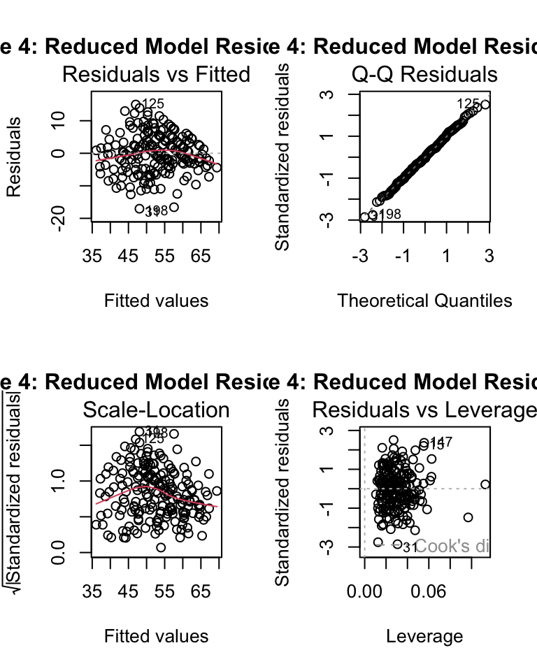

```r
par(mfrow = c(2, 2))
plot(reduced.model, main = "Figure 4: Reduced Model Residual Plots")
```

```r
shapiro.test(residuals(reduced.model))
```

```
    Shapiro-Wilk normality test

data:  residuals(reduced.model)
W = 0.99714, p-value = 0.9748
```

With `race`, `ses`, `schtyp`, and `prog` removed, the reduced model keeps `read`, `math`, `science`, `socst`, and `gender`. R² drops only slightly, from 0.622 to 0.602, for a much simpler model with far fewer coefficients.

The Q-Q plot tracks the reference line closely except for two tail points, and the Shapiro-Wilk test returns p ≈ 0.975, giving no evidence against normality of the residuals. The Residuals vs Fitted and Scale-Location plots, however, both show a visible bend in the red smoother line rather than a perfectly flat trend. Since a plain normality test doesn’t tell us whether that bend is meaningful, we check it directly with a Box-Cox transformation below.

## 2.3 Box-Cox Transformation Check

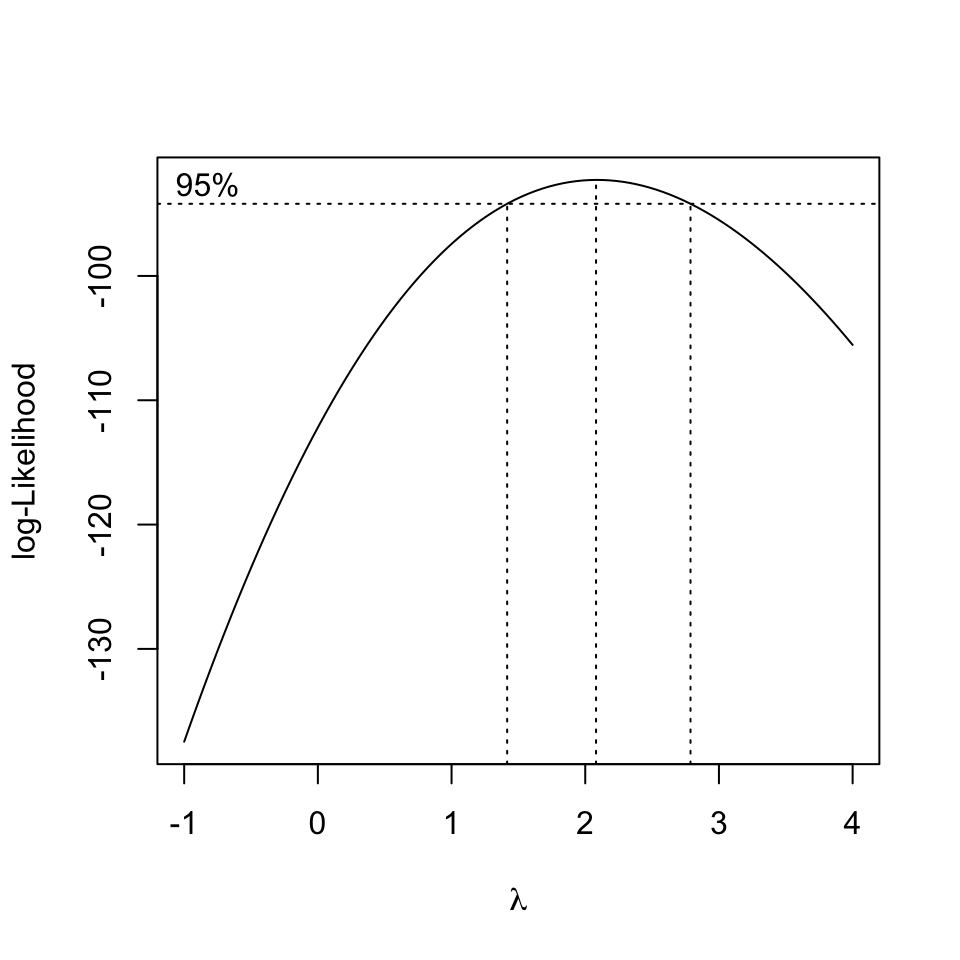

Figure 5: Box-Cox transformation of the reduced model.

```r
boxcox(reduced.model, lambda = seq(-1, 4, 0.1))
```

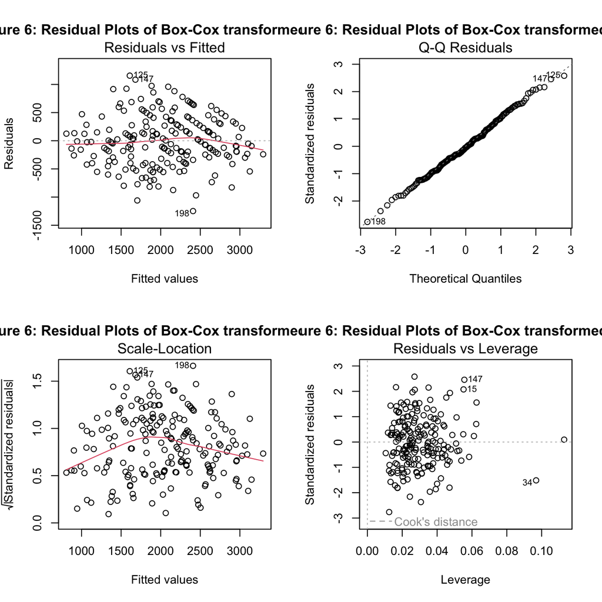

Residual plots of the Box-Cox transformed model.

```r
write <- hsb2$write
lambda   <- 2.1
write.bc <- (write^lambda - 1) / lambda
boxcox.model <- lm(write.bc ~ read + math + science + socst + gender, data = hsb2)

par(mfrow = c(2, 2))
plot(boxcox.model, main = "Figure 6: Residual Plots of Box-Cox transformed model")
```

```r
compare_table <- tibble(
  Model = c("write ~ ... (raw)", "Box-Cox transformed (lambda = 2.1)"),
  R_squared = c(summary(reduced.model)$r.squared, summary(boxcox.model)$r.squared),
  Shapiro_p = c(shapiro.test(residuals(reduced.model))$p.value,
                shapiro.test(residuals(boxcox.model))$p.value)
)
kable(compare_table, digits = 4, caption = "Raw vs. Box-Cox transformed model comparison")
```

Raw vs. Box-Cox transformed model comparison

| Model | R_squared | Shapiro_p |
| --- | --- | --- |
| write ~ … (raw) | 0.6017 | 0.9748 |
| Box-Cox transformed (lambda = 2.1) | 0.6046 | 0.9372 |

The transformed model shows almost no improvement. R² moves from 0.602 to 0.605, and the Shapiro-Wilk p-value actually decreases slightly, from 0.975 to 0.937, though both remain far from significant. More importantly, the bend visible in the Residuals vs Fitted and Scale-Location plots is essentially unchanged after transformation. This tells us the bend is not an issue that a power transformation can correct, but more likely reflects some nonlinearity in how one of the predictors relates to writing score. Given the negligible gain, **we retain the untransformed model** as our final model.

## 2.4 Goodness-of-Fit Comparison

Next, we extract several other goodness-of-fit from 2 candidate models and summarize them in the following table.

Since our final decision is between the full and reduced models, both on the original scale, SSE, AIC, SBC, and PRESS are all valid to compare directly.

```r
select <- function(m) {
  e   <- m$resid
  n0  <- length(e)
  SSE <- (m$df) * (summary(m)$sigma)^2
  R.sq  <- summary(m)$r.squared
  R.adj <- summary(m)$adj.r
  MSE   <- (summary(m)$sigma)^2
  Cp  <- (SSE / MSE) - (n0 - 2 * (n0 - m$df))
  AIC <- n0 * log(SSE) - n0 * log(n0) + 2 * (n0 - m$df)
  SBC <- n0 * log(SSE) - n0 * log(n0) + (log(n0)) * (n0 - m$df)
  X <- model.matrix(m)
  H <- X %*% solve(t(X) %*% X) %*% t(X)
  d <- e / (1 - diag(H))
  PRESS <- t(d) %*% d
  tbl <- as.data.frame(cbind(SSE = SSE, R.sq = R.sq, R.adj = R.adj,
                             Cp = Cp, AIC = AIC, SBC = SBC, PRD = PRESS))
  names(tbl) <- c("SSE", "R.sq", "R.adj", "Cp", "AIC", "SBC", "PRESS")
  tbl
}

output.sum <- rbind(select(full.model), select(reduced.model))
row.names(output.sum) <- c("full.model", "reduced.model")
kable(output.sum, digits = 3, caption = "Goodness-of-fit Measures of Candidate Models")
```

Goodness-of-fit Measures of Candidate Models

|  | SSE | R.sq | R.adj | Cp | AIC | SBC | PRESS |
| --- | --- | --- | --- | --- | --- | --- | --- |
| full.model | 6757.994 | 0.622 | 0.596 | 14 | 732.033 | 778.209 | 7845.045 |
| reduced.model | 7121.951 | 0.602 | 0.591 | 6 | 726.524 | 746.314 | 7577.151 |

The reduced model has a slightly lower R² at 0.602, but a nearly identical adjusted R² at 0.591 and 0.596, and clearly better AIC, SBC, and PRESS than the full model, since it achieves almost the same fit with far fewer parameters. After comparing the two models, **we choose the reduced model as our final model.**

## 2.5 Final Model

In this section we will finalize our model after reducing variable and confirming normality assumptions

```r
kable(summary(reduced.model)$coef, digits = 4,
      caption = "Inferential Statistics of Final Model")
```

Inferential Statistics of Final Model

|  | Estimate | Std. Error | t value | Pr(>\|t\|) |
| --- | --- | --- | --- | --- |
| (Intercept) | 11.6313 | 2.7558 | 4.2206 | 0.0000 |
| read | 0.1254 | 0.0650 | 1.9306 | 0.0550 |
| math | 0.2381 | 0.0671 | 3.5467 | 0.0005 |
| science | 0.2419 | 0.0607 | 3.9858 | 0.0001 |
| socst | 0.2293 | 0.0528 | 4.3392 | 0.0000 |
| gendermale | -5.4925 | 0.8754 | -6.2741 | 0.0000 |

We can explicitly write the final model as

$$\widehat{write} = 11.63 + 0.13\times read + 0.24\times math + 0.24\times
science + 0.23\times socst - 5.49\times gender_{male}$$

Since none of the variables were transformed, every coefficient has a direct practical interpretation. Holding the other test scores and gender constant, a one-point increase in math score is associated with about a 0.24-point increase in writing score; science and social studies scores show similar associations (about 0.23-0.24 points each). Reading score has a smaller association (0.13 points) and is only borderline significant (p ≈ 0.055) once the other three test scores are already in the model, since they are all correlated with each other. Male students are predicted to score about 5.49 points lower on writing than female students, holding all test scores constant - the single largest effect in the model.

# 3 Bootstrap Confidence Intervals

Even though the residual diagnostics for this model already look good, we still construct bootstrap confidence intervals, since this provides an assumption-free cross-check on the OLS inference.

```r
B <- 5000
n <- nrow(hsb2)

boot.coefs <- matrix(NA, nrow = B, ncol = length(coef(reduced.model)))
colnames(boot.coefs) <- names(coef(reduced.model))

for (i in 1:B) {
  boot.id  <- sample(1:n, n, replace = TRUE)
  boot.fit <- lm(write ~ read + math + science + socst + gender,
                  data = hsb2[boot.id, ])
  boot.coefs[i, ] <- coef(boot.fit)
}

boot.ci <- t(apply(boot.coefs, 2, quantile, probs = c(0.025, 0.975)))
pander(boot.ci, caption = "95% Bootstrap Confidence Intervals - Reduced MLR Model")
```

95% Bootstrap Confidence Intervals - Reduced MLR Model

|  | 2.5% | 97.5% |
| --- | --- | --- |
| **(Intercept)** | 6.532 | 16.61 |
| **read** | 0.009651 | 0.2443 |
| **math** | 0.1058 | 0.3734 |
| **science** | 0.1186 | 0.3706 |
| **socst** | 0.1168 | 0.342 |
| **gendermale** | -7.237 | -3.672 |

```r
ols.ci <- confint(reduced.model, level = 0.95)
comparison <- data.frame(
  Variable         = rownames(ols.ci),
  OLS_Lower        = round(ols.ci[, 1], 4),
  OLS_Upper        = round(ols.ci[, 2], 4),
  Bootstrap_Lower  = round(boot.ci[, 1], 4),
  Bootstrap_Upper  = round(boot.ci[, 2], 4)
)
pander(comparison, caption = "95% Confidence Intervals: OLS vs. Bootstrap")
```

95% Confidence Intervals: OLS vs. Bootstrap (continued below)

|  | Variable | OLS_Lower | OLS_Upper | Bootstrap_Lower |
| --- | --- | --- | --- | --- |
| **(Intercept)** | (Intercept) | 6.196 | 17.07 | 6.532 |
| **read** | read | -0.0027 | 0.2535 | 0.0097 |
| **math** | math | 0.1057 | 0.3705 | 0.1058 |
| **science** | science | 0.1222 | 0.3617 | 0.1186 |
| **socst** | socst | 0.1251 | 0.3335 | 0.1168 |
| **gendermale** | gendermale | -7.219 | -3.766 | -7.237 |

|  | Bootstrap_Upper |
| --- | --- |
| **(Intercept)** | 16.61 |
| **read** | 0.2443 |
| **math** | 0.3734 |
| **science** | 0.3706 |
| **socst** | 0.342 |
| **gendermale** | -3.672 |

The OLS and bootstrap confidence intervals agree closely across every coefficient, which is expected given that the reduced model’s residuals already satisfied the normality assumption.

# 4 Discussion

We started with a full model including every available predictor, checked for multicollinearity with VIF and used significance testing to drop four insignificant categorical predictors (`race`, `ses`, `schtyp`, `prog`). This resulted in a simpler model with variables `read`, `math`, `science`, `socst`, and `gender`. The reduced model’s residuals passed a formal normality test, but a visible bend remained in the red lines in the Residuals vs Fitted and Scale-Location plots. We checked this directly with a Box-Cox transformation. The transformation produced a negligible improvement in fit and normality, and the bend itself was still there. Therefore we kept the model in its original scale. The goodness-of-fit comparison supported keeping the simpler model over the full one, and the bootstrap confidence intervals closely matched the OLS results, reinforcing that math score, science score, social studies score, and gender are all reliably associated with writing score, with gender showing the largest single effect.

Our practical question asked which factors are associated with a student’s writing score. The final model directly answers this: math score (p = 0.0005), science score (p = 0.0001), social studies score (p < 0.0001), and gender (p < 0.0001) are all statistically significant predictors of writing score at the $\alpha = 0.05$ level, while reading score (p = 0.0550) falls just short of conventional significance once the other three test scores are already accounted for. This does not mean reading ability is unrelated to writing ability - the pairwise scatter plot in the exploratory analysis showed a clear positive correlation between the two (r = 0.60) - it means that once math, science, and social studies scores are already in the model, reading score adds comparatively little *additional* explanatory power, since all four test scores are correlated with one another.

Gender is the single strongest and most reliable predictor: male students are predicted to score about 5.49 points lower on writing than female students (95% CI: 3.78 to 7.22 points lower, from both the OLS and bootstrap intervals), holding all test scores constant. Because both inference methods agree so closely, we have strong evidence this difference is real rather than a byproduct of any residual assumption violation.

Notably, none of the categorical variables originally hypothesized to matter for this question - socioeconomic status (`ses`) and academic program (`prog`) - were statistically significant once test scores and gender were accounted for (both were removed during variable selection). This means that, at least for this data set, a student’s own academic performance and gender are more directly tied to writing score than their socioeconomic background or program track. The model overall explains about 60.2% of the variation in writing scores ($R^2 = 0.602$), indicating other unmeasured factors also play a meaningful role.